# Introducing R/Tidyverse to Clinical Statistical Programming

MBSW 2018

Freeman Wang, @freestatman

2018-05-15 Slides available at https://bit.ly/2KNKALU

# Disclaimer

1. All the data and info in this talk are public (Twitter, GitHub).
   - CDISC example data were downloaded from: [GitHub](https://github.com/phuse-org/phuse-scripts/tree/master/data)
2. This talk represents my own views, not those of BSSI.
   - BSSI does not have an opinion of which tool you should use: e.g. SAS vs R, or R/base vs R/Tidyverse.

# Why? Why so popular (1/2)

- **Not** about the good-looking plots, or the fancy manipulation functions
- Content-driven and communication-focused workflow (logic-flow)
- Concisely expresses human logic as R code
  - Fast human logic I/O
  - Yourself ↔️ team / customer
  - Past you ➡️ present you
- Seamlessly align multiple layers of logic, across analysis objective, programming, and output

# Why? Why so popular (2/2)

- structured domains of workflow, and well-defined verb/vocabulary within each domain
- grammer of data manipulation (dplyr)
- grammer of data visualizaiton (ggplot2)
- grammer of statistics (not mature yet… SAS is the standard.)
- consistent design:
- **learn it once, use it everywhere**

# How? Tidy principles

1. Tidy data (Shared data structures)
2. Tidy programming API (Compose simple pieces)
3. The pipe! (functional programming for Human logic)
4. Tidy statistics

# Tidyverse: more packages

Clinical programming is one of Data Science

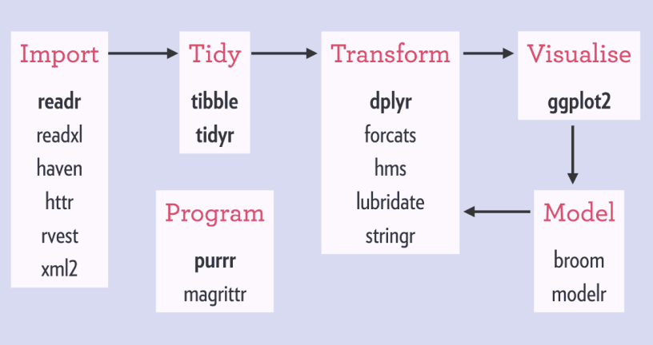

# A “Real” Tidyverse [Workflow](http://r4ds.had.co.nz/introduction-1.html)

[figure not shown]

# What? Tidy data

- Each row is an observation
- Each column is a variable
- Clnical data
- Long-format is commonly seen in data storage, e.g. SDTM/ADaM
- Wide-format is commonly seen for DEA, modeling, and visualization
- Align manipulaiton, statistical and visualization logic with tidy data

# What? Grammer of data manipulation

- `dplyr`, key verbs
- `select` (common verb in SQL)
- `mutate` (e.g. case_when)
- `filter`
- `group_by`
- `summarize`
- `arrange`
- Translatable to SQL
- [Cheatsheet](https://github.com/rstudio/cheatsheets/raw/master/data-transformation.pdf)

# Example of Why, How&What

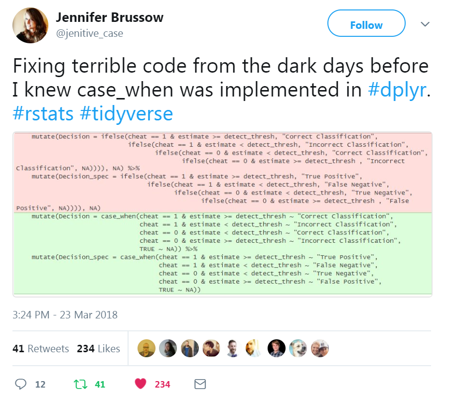

- Align your manipulation visually and logically
- Convert your raw coding to more consumable coding (shorten the logic gap)

# What? Tidyverse extended families

From the community * [ggplot2 extention packages](http://www.ggplot2-exts.org/gallery/) - survminer, cowplot, etc * [plotly](https://plotly-book.cpsievert.me/) * summarytools * janitor * tidyversity * [jsmisc](https://github.com/strengejacke/sjmisc) * More bioconductor packages buys in!

# Example

```r
library(haven)
library(tidyverse)
iris <- haven::read_sas('data/iris.sas7bdat')
adsl <- Hmisc::sasxport.get("data/adam/cdisc/adsl.xpt")
```

```
## Processing SAS dataset ADSL   ..
```

```r
adsl %>%
    select(usubjid, contains('trt')) %>%
    DT::datatable(options = list(pageLength = 3))
```

|  | usubjid | trt01p | trt01pn | trt01a | trt01an | trtsdt | trtedt | trtdur |
| --- | --- | --- | --- | --- | --- | --- | --- | --- |
| 1 | 01-701-1015 | Placebo | 0 | Placebo | 0 | 2014-01-02 | 2014-07-02 | 182 |
| 2 | 01-701-1023 | Placebo | 0 | Placebo | 0 | 2012-08-05 | 2012-09-01 | 28 |
| 3 | 01-701-1028 | Xanomeline High Dose | 81 | Xanomeline High Dose | 81 | 2013-07-19 | 2014-01-14 | 180 |
| 4 | 01-701-1033 | Xanomeline Low Dose | 54 | Xanomeline Low Dose | 54 | 2014-03-18 | 2014-03-31 | 14 |
| 5 | 01-701-1034 | Xanomeline High Dose | 81 | Xanomeline High Dose | 81 | 2014-07-01 | 2014-12-30 | 183 |
| 6 | 01-701-1047 | Placebo | 0 | Placebo | 0 | 2013-02-12 | 2013-03-09 | 26 |
| 7 | 01-701-1097 | Xanomeline Low Dose | 54 | Xanomeline Low Dose | 54 | 2014-01-01 | 2014-07-09 | 190 |
| 8 | 01-701-1111 | Xanomeline Low Dose | 54 | Xanomeline Low Dose | 54 | 2012-09-07 | 2012-09-16 | 10 |
| 9 | 01-701-1115 | Xanomeline Low Dose | 54 | Xanomeline Low Dose | 54 | 2012-11-30 | 2013-01-23 | 55 |
| 10 | 01-701-1118 | Placebo | 0 | Placebo | 0 | 2014-03-12 | 2014-09-09 | 182 |

[output cut: 244 more lines]

# The pipe! %>%

- Conceptually the same with Unix pipe snytax
- Push the LHS output into the 1st argument of the RHS function
- Natural representation of human logic
- Each layer of process is a function
- Enbrace Functional programming
- Similar philosophy to ggplot2
- Grammar of Graphics

# #TidyTuesday

[figure not shown]

# #TidyTuesday

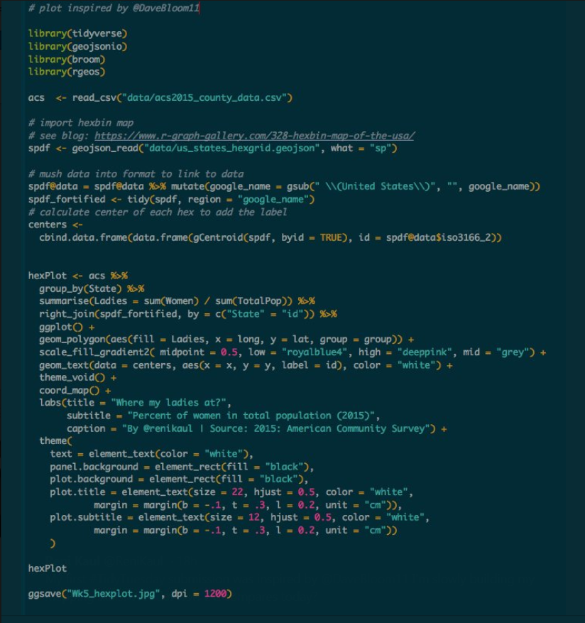

# Discussion

- R/Tidyverse is fast growing
  - Adpoting new idea
  - Some rare API change caused some pain for R package developers (OK for general users)
- Enviroment/Namespace control is a common R problem
  - Loaded functions may be over-writen by loading other packages
  - More robust usage is to add package namespace: `dplyr::select()`